# FD models

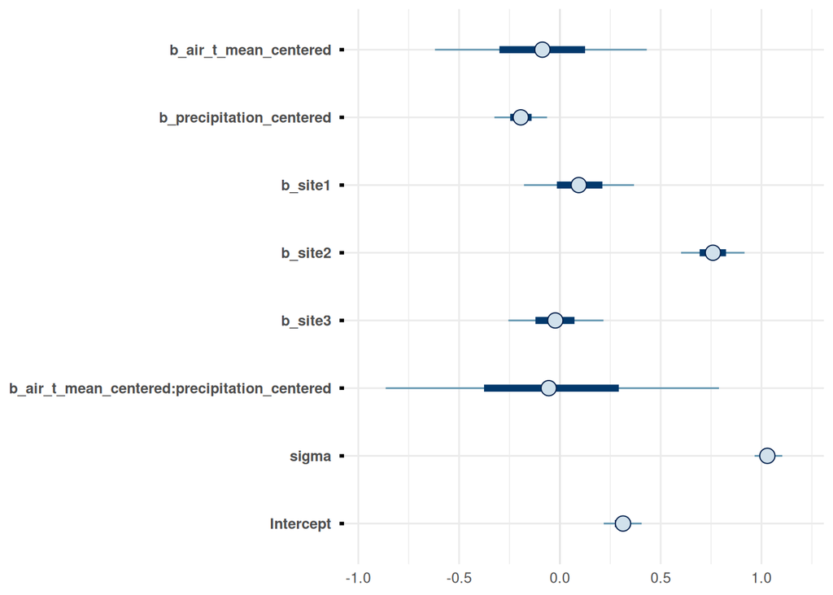

```r
mcmc_intervals(fit_overl_ofd, pars = show)
```

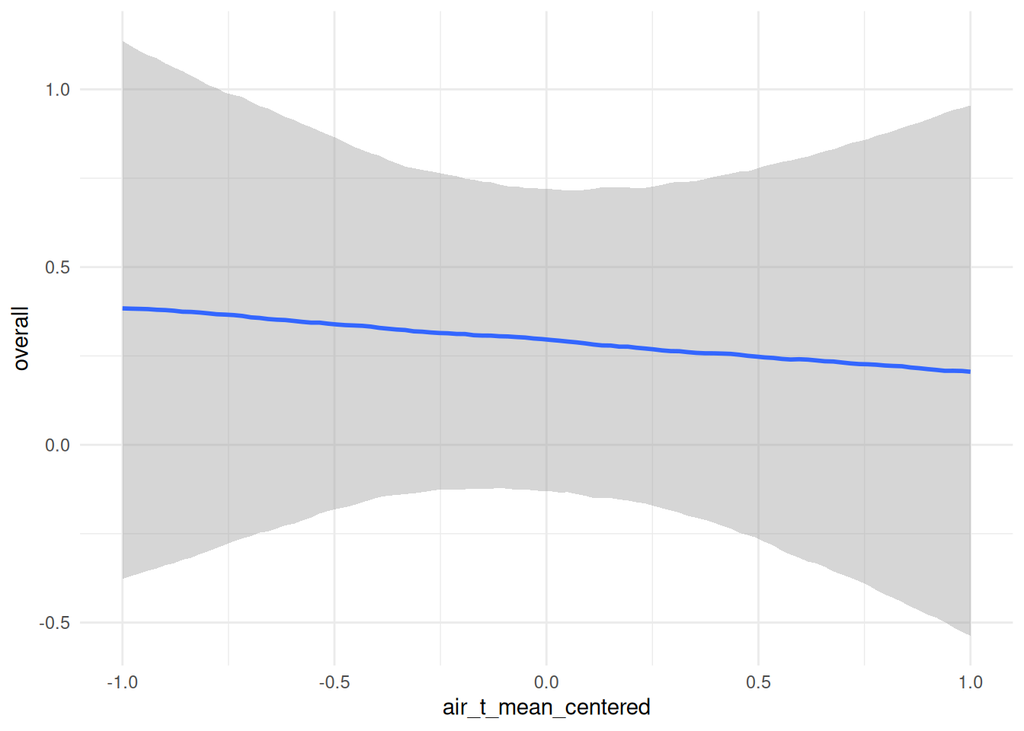

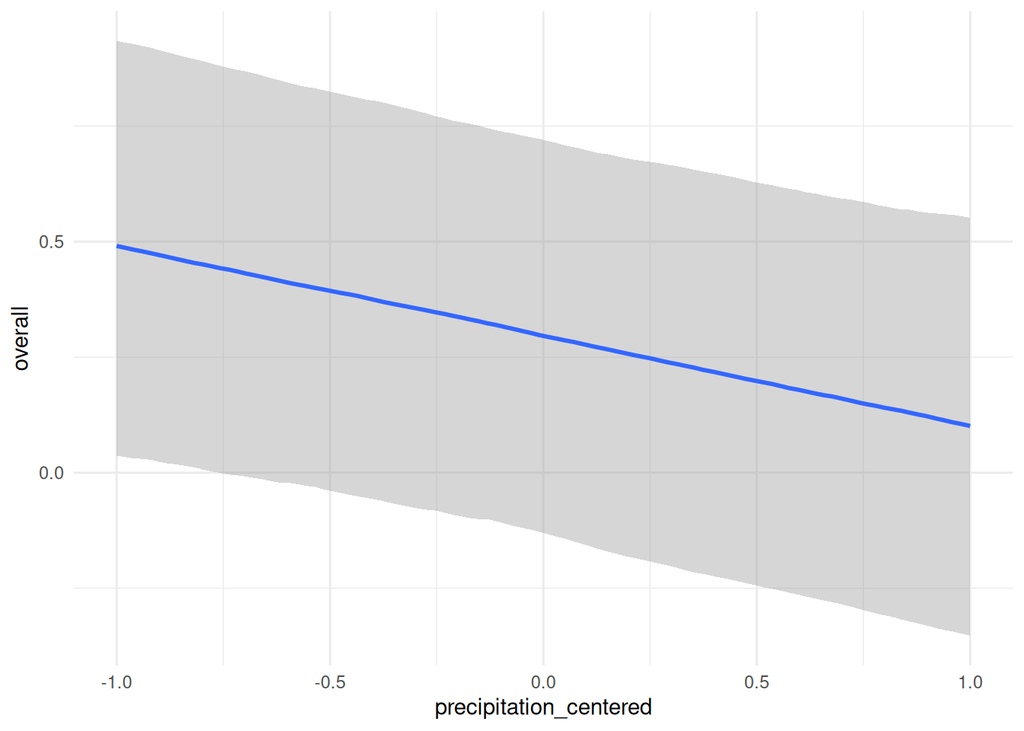

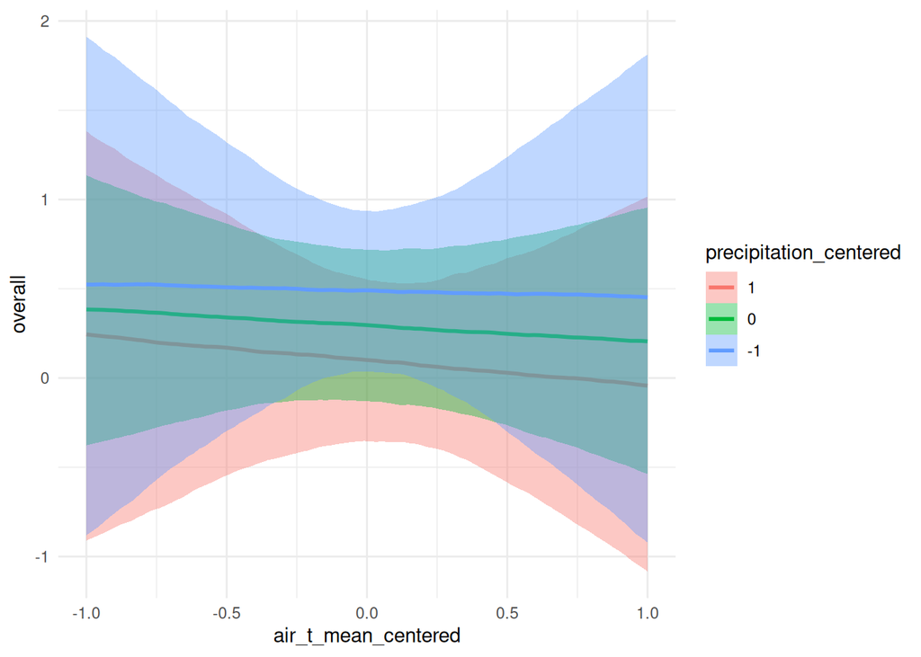

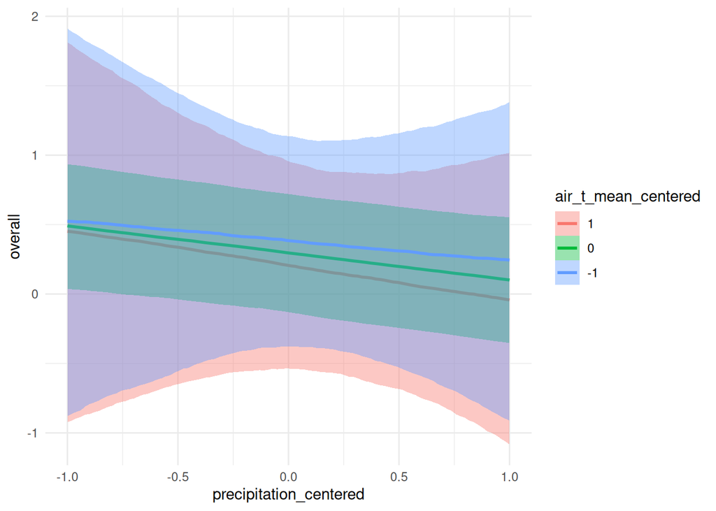

```r
my_ceffects(fit_overl_ofd)
```

# 9 Sub-canopy weather models

The main difference with the open-field models is that the models are fit to multiply imputed datasets (m = 5), instead of complete-case analysis. The procedure is mostly the same, but the plotted data points use as weather values those of the first imputation.

**Note:** [brms 2.23.0 ignores the seed argument for `brm_multiple`](https://github.com/paul-buerkner/brms/issues/1862). This will be fixed in 2.24.0, for now the workaround is to specify “seed” in the control list.

## 9.1 Aboveground FD

Models for the total effect of air temperature, precipitation, and their interaction on aboveground FD-SES.

```r
fit_above_itp <-  brm_multiple(above ~ air_t_mean_centered + precipitation_centered +
                                 air_t_mean_centered:precipitation_centered +
                                 cover + site,
                               data = above_itp,
                               prior = prior_itp,
                               file = "fits/fd/above.itp",
                               file_refit = "never",
                               control = list(seed = 2853))

prior_summary(fit_above_itp)
```

| prior | class | coef | group | resp | dpar | nlpar | lb | ub | tag | source |
| --- | --- | --- | --- | --- | --- | --- | --- | --- | --- | --- |
| normal(0, 1) | b |  |  |  |  |  |  |  |  | user |
|  | b | air_t_mean_centered |  |  |  |  |  |  |  | default |
|  | b | air_t_mean_centered:precipitation_centered |  |  |  |  |  |  |  | default |
|  | b | cover |  |  |  |  |  |  |  | default |
|  | b | precipitation_centered |  |  |  |  |  |  |  | default |
| student_t(3, 0, 0.7) | b | site1 |  |  |  |  |  |  |  | user |
| student_t(3, 0, 0.7) | b | site2 |  |  |  |  |  |  |  | user |
| student_t(3, 0, 0.7) | Intercept |  |  |  |  |  |  |  |  | user |
| student_t(3, 0, 0.5) | sigma |  |  |  |  |  | 0 |  |  | user |

```r
fit_above_itp
```

```
 Family: gaussian
  Links: mu = identity
Formula: above ~ air_t_mean_centered + precipitation_centered + air_t_mean_centered:precipitation_centered + cover + site
   Data: above_itp (Number of observations: 318)
  Draws: 20 chains, each with iter = 2000; warmup = 1000; thin = 1;
         total post-warmup draws = 20000

Regression Coefficients:
                                           Estimate Est.Error l-95% CI u-95% CI
Intercept                                      4.80      1.92     0.96     8.53
air_t_mean_centered                           -0.42      0.43    -1.24     0.42
precipitation_centered                        -0.06      0.13    -0.31     0.19
cover                                         -1.04      0.53    -2.08     0.02
site1                                          0.72      0.16     0.40     1.05
site2                                          0.57      0.15     0.27     0.86
air_t_mean_centered:precipitation_centered    -0.23      0.62    -1.45     0.99

Further Distributional Parameters:
      Estimate Est.Error l-95% CI u-95% CI
sigma     1.33      0.05     1.23     1.44

Draws were sampled using sample(hmc). Overall Rhat and ESS estimates
are not informative for brm_multiple models and are hence not displayed.
Please see ?brm_multiple for how to assess convergence of such models.
```

```r
multiple_convergence(fit_above_itp)
```

| variable | rhat | ess_bulk | ess_tail |
| --- | --- | --- | --- |
| b_Intercept | 1 | 2335 | 2664 |
| b_air_t_mean_centered | 1 | 3034 | 2834 |
| b_precipitation_centered | 1 | 2939 | 2937 |
| b_cover | 1 | 2367 | 2771 |
| b_site1 | 1 | 3065 | 2552 |
| b_site2 | 1 | 2105 | 2400 |
| b_air_t_mean_centered:precipitation_centered | 1 | 2878 | 2856 |
| sigma | 1 | 3920 | 2682 |
| Intercept | 1 | 4048 | 2850 |

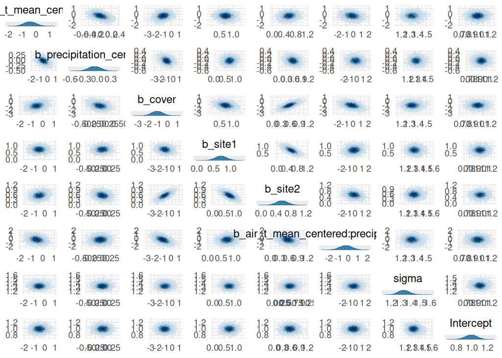

```r
my_mcmc_pairs(fit_above_itp)
```

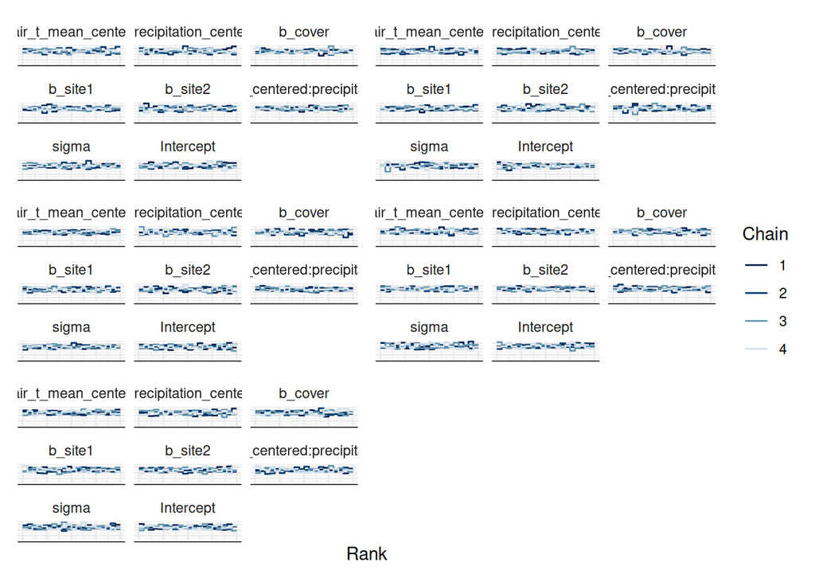

```r
trank(fit_above_itp)
```

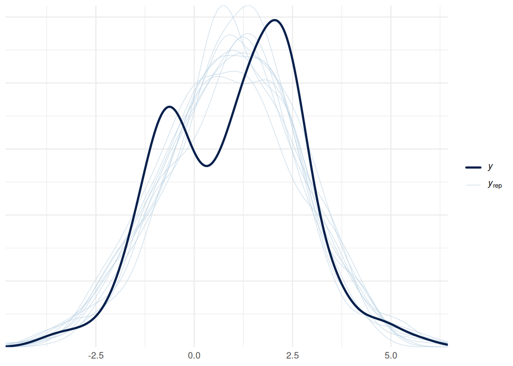

```r
pp_check(fit_above_itp)
```

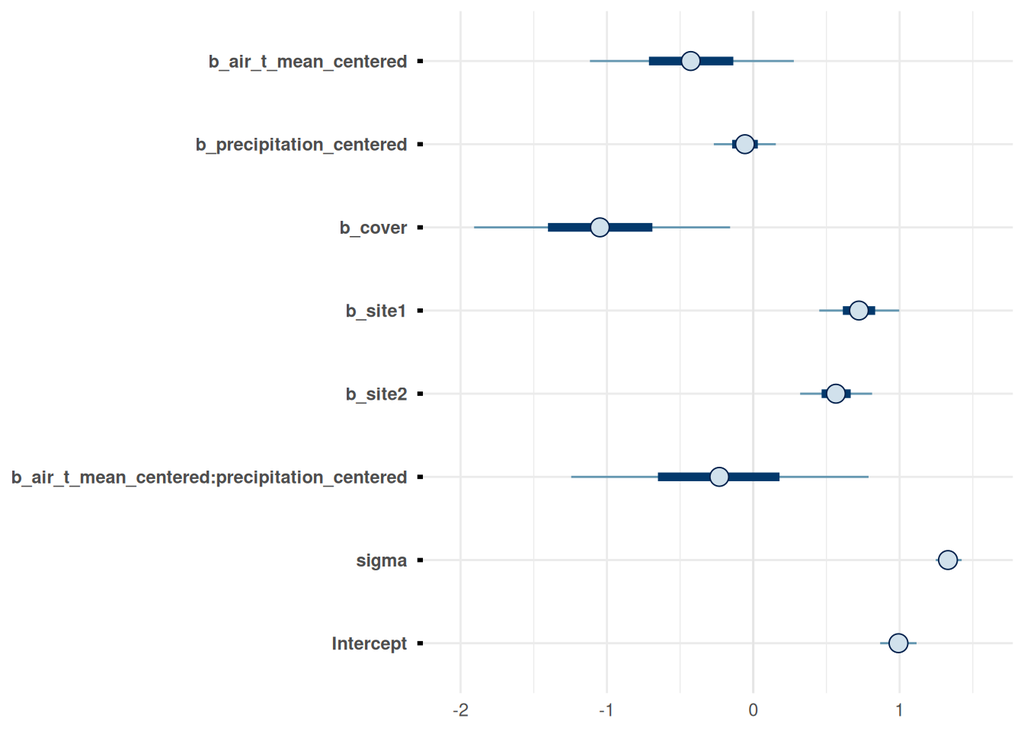

```r
mcmc_intervals(fit_above_itp, pars = show)
```

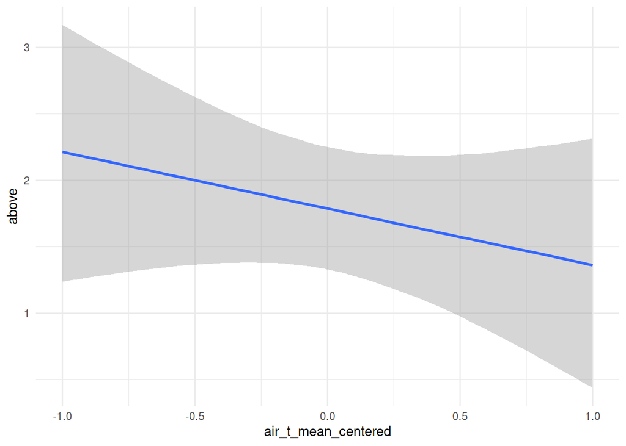

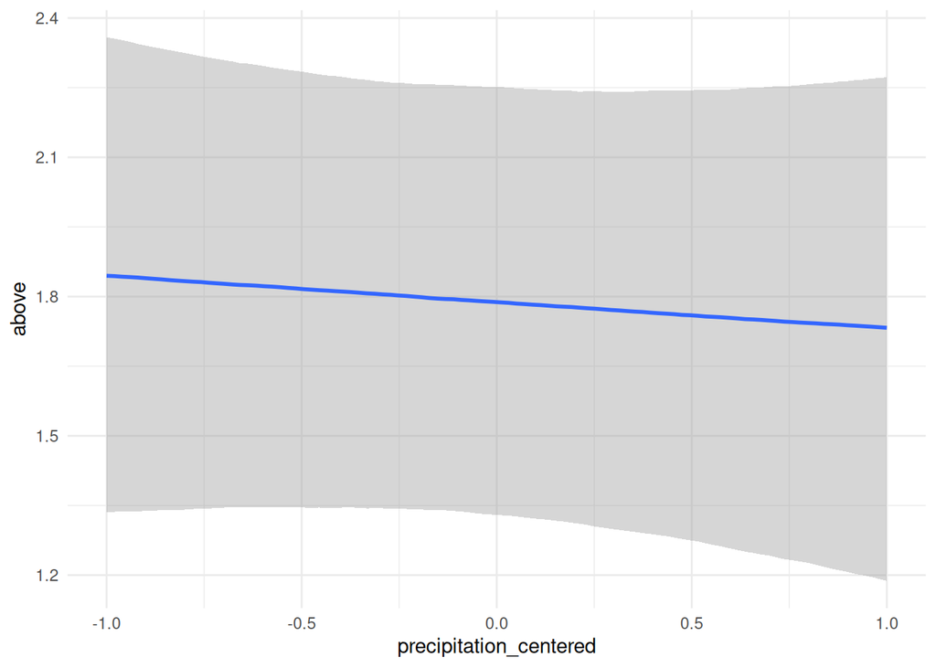

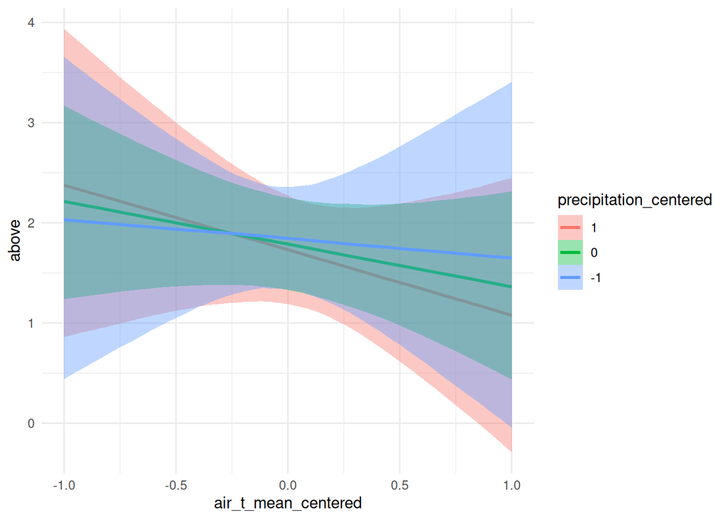

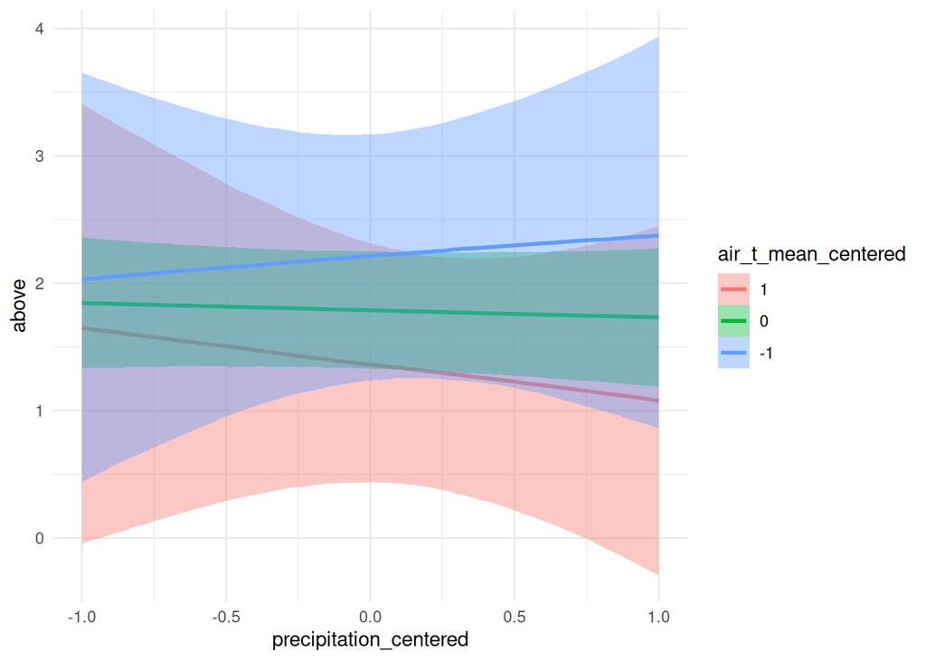

```r
my_ceffects(fit_above_itp)
```

## 9.2 Belowground FD

Models for the total effect of soil temperature, precipitation, and their interaction on belowgroumd FD-SES.

```r
fit_below_itp <-  brm_multiple(below ~ soil_t_mean_centered + precipitation_centered +
                                 soil_t_mean_centered:precipitation_centered +
                                 cover + site,
                               data = below_itp,
                               prior = prior_itp,
                               file = "fits/fd/below.itp",
                               file_refit = "never",
                               control = list(seed = 2853))

prior_summary(fit_below_itp)
```

| prior | class | coef | group | resp | dpar | nlpar | lb | ub | tag | source |
| --- | --- | --- | --- | --- | --- | --- | --- | --- | --- | --- |
| normal(0, 1) | b |  |  |  |  |  |  |  |  | user |
|  | b | cover |  |  |  |  |  |  |  | default |
|  | b | precipitation_centered |  |  |  |  |  |  |  | default |
| student_t(3, 0, 0.7) | b | site1 |  |  |  |  |  |  |  | user |
| student_t(3, 0, 0.7) | b | site2 |  |  |  |  |  |  |  | user |
|  | b | soil_t_mean_centered |  |  |  |  |  |  |  | default |
|  | b | soil_t_mean_centered:precipitation_centered |  |  |  |  |  |  |  | default |
| student_t(3, 0, 0.7) | Intercept |  |  |  |  |  |  |  |  | user |
| student_t(3, 0, 0.5) | sigma |  |  |  |  |  | 0 |  |  | user |

```r
fit_below_itp
```

```
 Family: gaussian
  Links: mu = identity
Formula: below ~ soil_t_mean_centered + precipitation_centered + soil_t_mean_centered:precipitation_centered + cover + site
   Data: below_itp (Number of observations: 318)
  Draws: 20 chains, each with iter = 2000; warmup = 1000; thin = 1;
         total post-warmup draws = 20000

Regression Coefficients:
                                            Estimate Est.Error l-95% CI
Intercept                                      -2.12      1.34    -4.71
soil_t_mean_centered                            0.05      0.49    -0.89
precipitation_centered                         -0.15      0.09    -0.34
cover                                           0.48      0.37    -0.24
site1                                          -0.14      0.12    -0.37
site2                                           0.33      0.11     0.12
soil_t_mean_centered:precipitation_centered    -0.25      0.62    -1.49
                                            u-95% CI
Intercept                                       0.50
soil_t_mean_centered                            1.04
precipitation_centered                          0.02
cover                                           1.20
site1                                           0.10
site2                                           0.54
soil_t_mean_centered:precipitation_centered     0.94

Further Distributional Parameters:
      Estimate Est.Error l-95% CI u-95% CI
sigma     0.95      0.04     0.88     1.03

Draws were sampled using sample(hmc). Overall Rhat and ESS estimates
are not informative for brm_multiple models and are hence not displayed.
Please see ?brm_multiple for how to assess convergence of such models.
```

```r
multiple_convergence(fit_below_itp)
```

| variable | rhat | ess_bulk | ess_tail |
| --- | --- | --- | --- |
| b_Intercept | 1 | 2592 | 2670 |
| b_soil_t_mean_centered | 1 | 2999 | 2695 |
| b_precipitation_centered | 1 | 3123 | 2781 |
| b_cover | 1 | 2621 | 2654 |
| b_site1 | 1 | 2835 | 2737 |
| b_site2 | 1 | 2085 | 2221 |
| b_soil_t_mean_centered:precipitation_centered | 1 | 3058 | 2775 |
| sigma | 1 | 3953 | 2438 |
| Intercept | 1 | 3895 | 2710 |

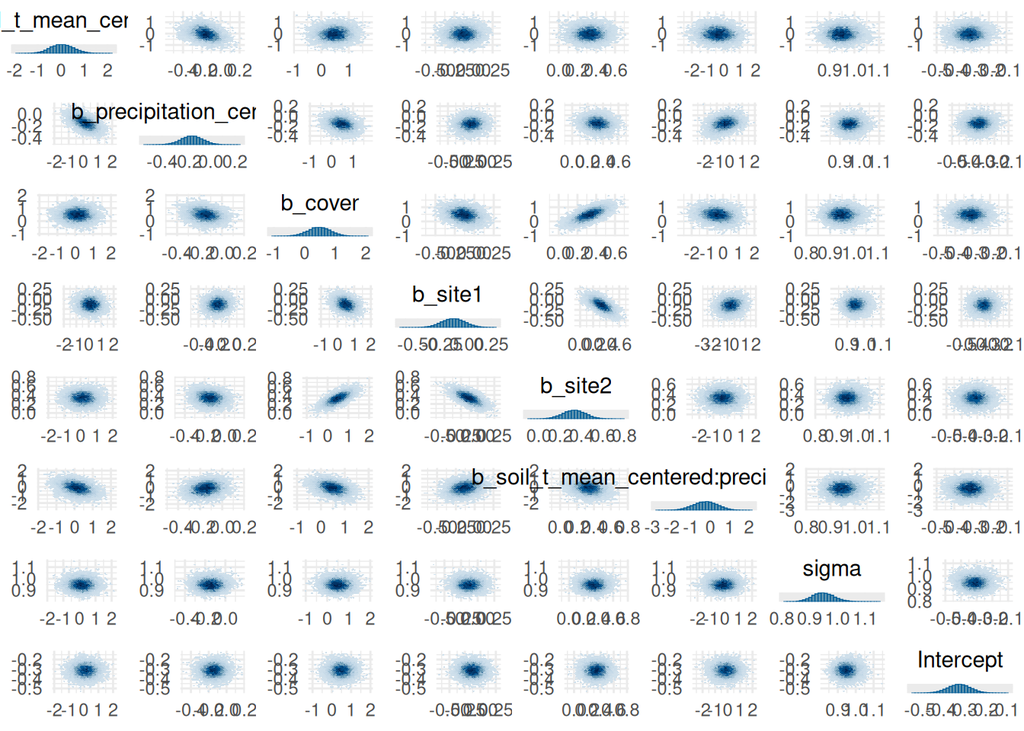

```r
my_mcmc_pairs(fit_below_itp)
```

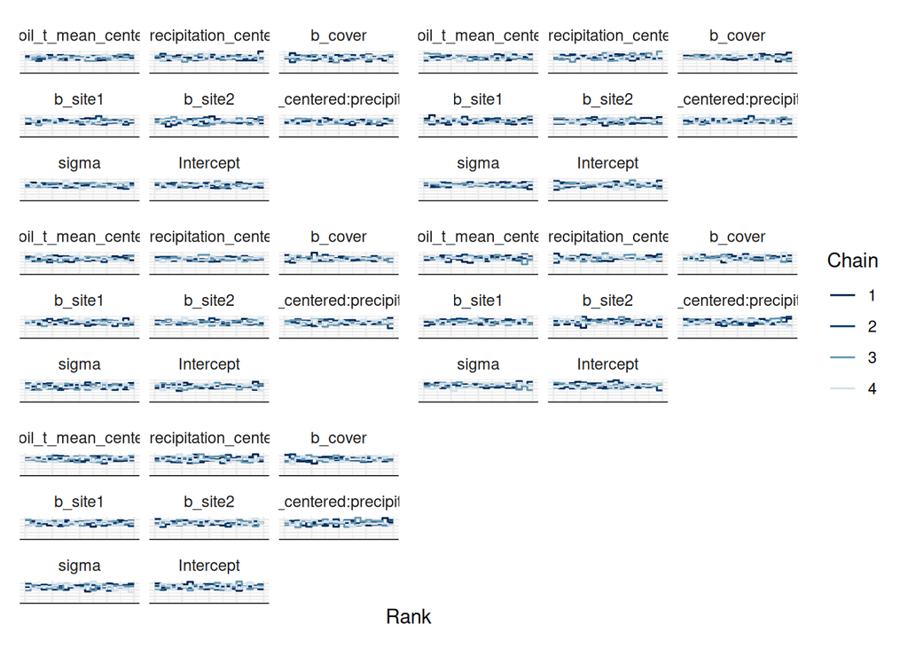

```r
trank(fit_below_itp)
```

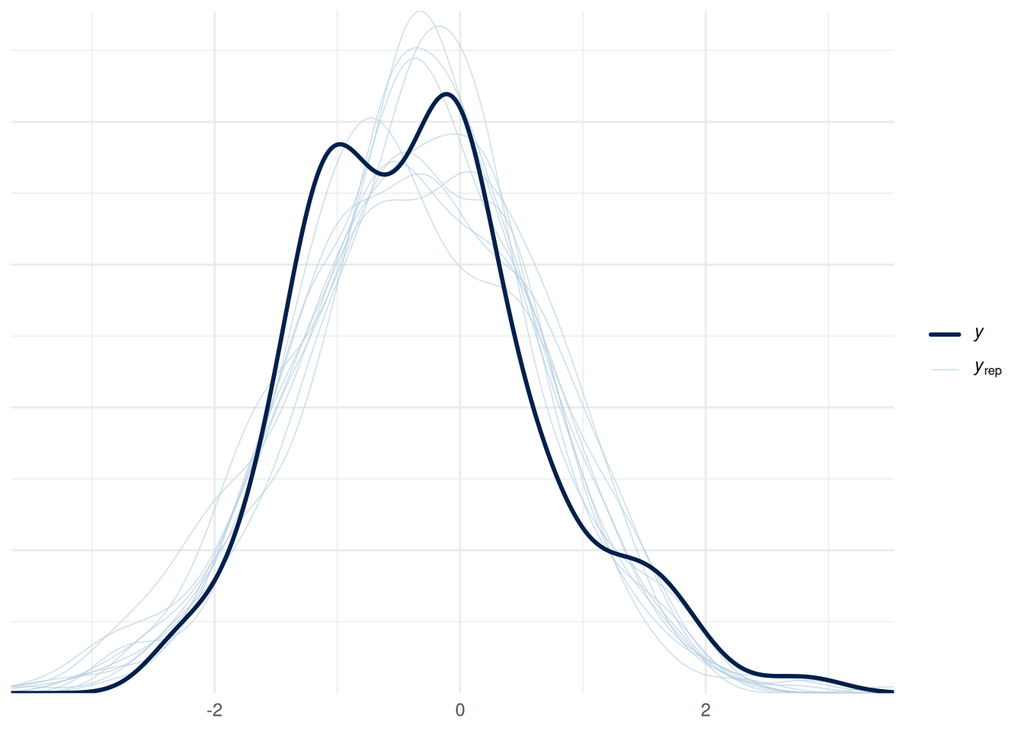

```r
pp_check(fit_below_itp)
```

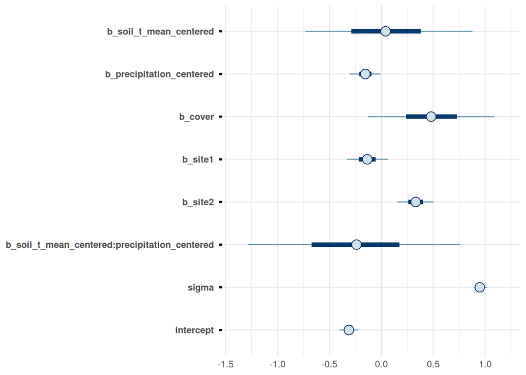

```r
mcmc_intervals(fit_below_itp, pars = show)
```

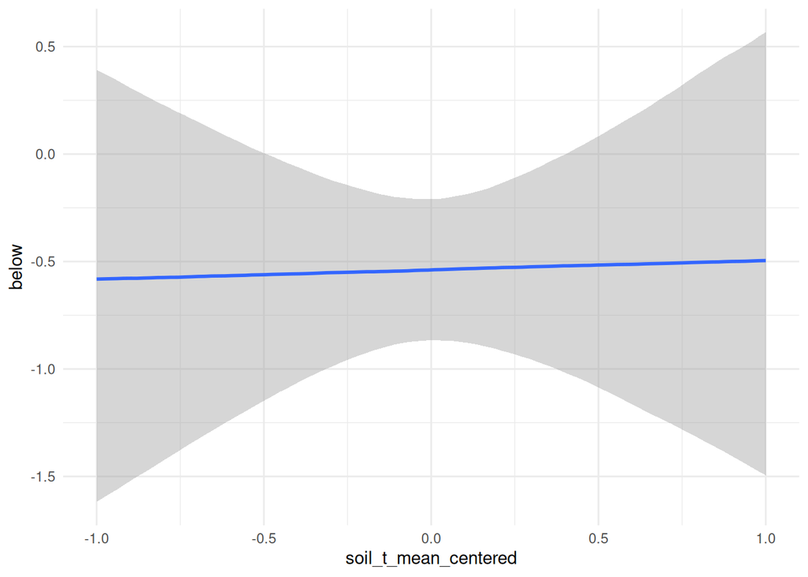

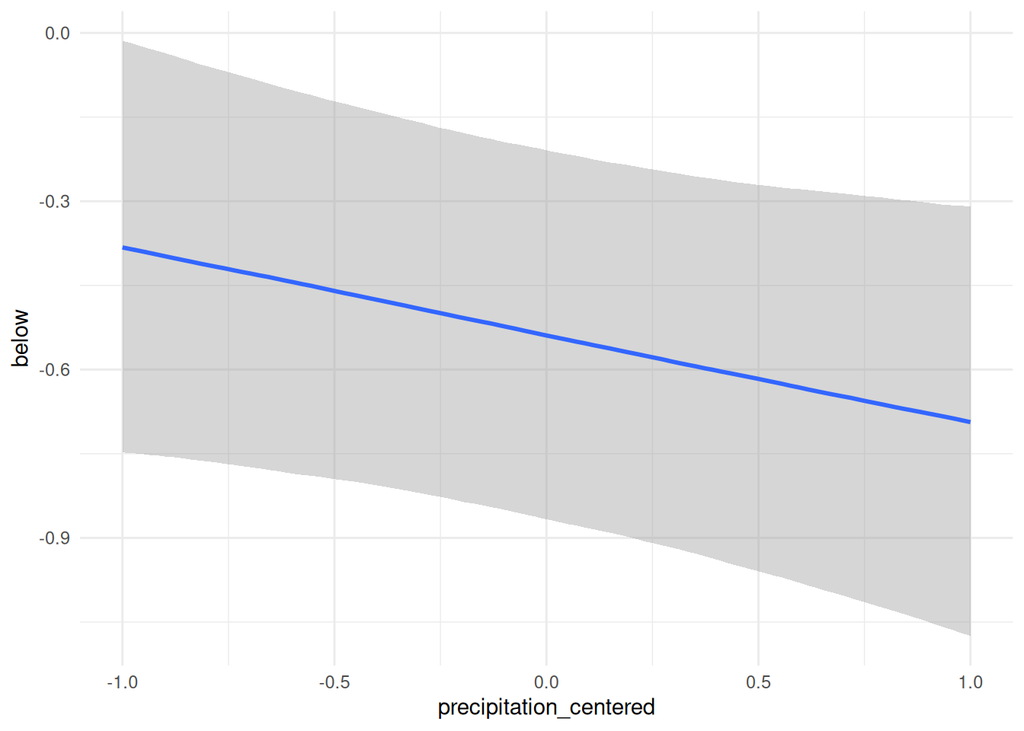

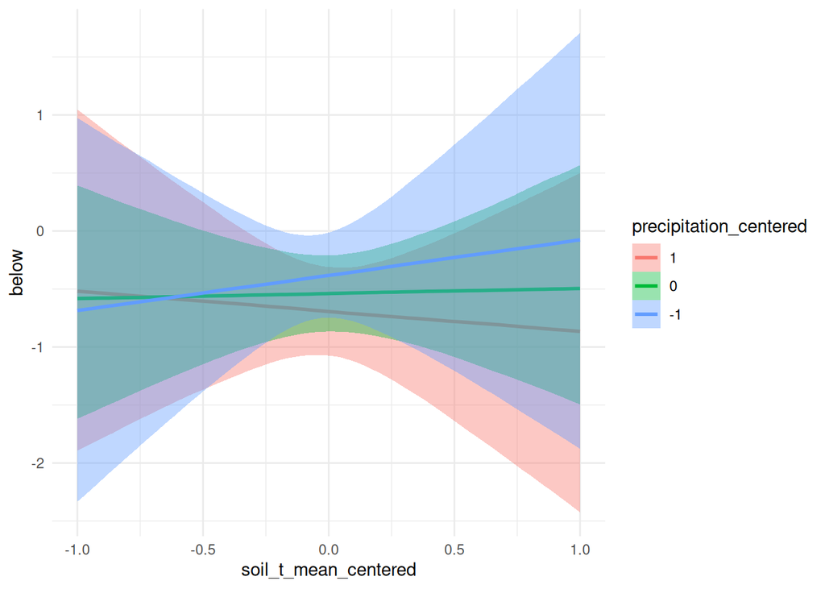

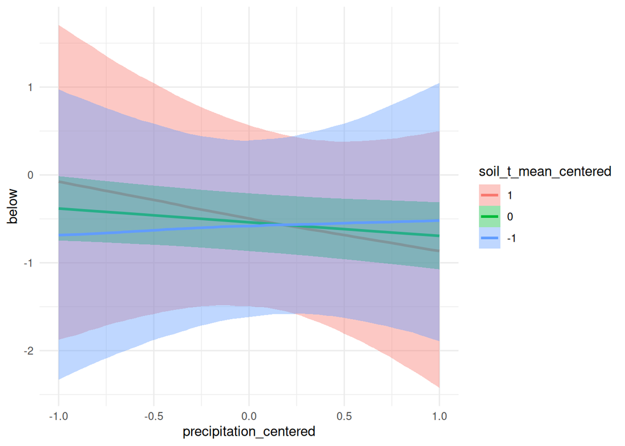

```r
my_ceffects(fit_below_itp)
```

## 9.3 Overall FD

Models for the total effect of air temperature, precipitation, and their interaction on overall FD-SES.

```r
fit_overl_itp <-  brm_multiple(overall ~ air_t_mean_centered + precipitation_centered +
                                 air_t_mean_centered:precipitation_centered +
                                 cover + site,
                               data = overl_itp,
                               prior = prior_itp,
                               file = "fits/fd/overl.itp",
                               file_refit = "never",
                               control = list(seed = 2853))

prior_summary(fit_overl_itp)
```

| prior | class | coef | group | resp | dpar | nlpar | lb | ub | tag | source |
| --- | --- | --- | --- | --- | --- | --- | --- | --- | --- | --- |
| normal(0, 1) | b |  |  |  |  |  |  |  |  | user |
|  | b | air_t_mean_centered |  |  |  |  |  |  |  | default |
|  | b | air_t_mean_centered:precipitation_centered |  |  |  |  |  |  |  | default |
|  | b | cover |  |  |  |  |  |  |  | default |
|  | b | precipitation_centered |  |  |  |  |  |  |  | default |
| student_t(3, 0, 0.7) | b | site1 |  |  |  |  |  |  |  | user |
| student_t(3, 0, 0.7) | b | site2 |  |  |  |  |  |  |  | user |
| student_t(3, 0, 0.7) | Intercept |  |  |  |  |  |  |  |  | user |
| student_t(3, 0, 0.5) | sigma |  |  |  |  |  | 0 |  |  | user |

```r
fit_overl_itp
```

```
 Family: gaussian
  Links: mu = identity
Formula: overall ~ air_t_mean_centered + precipitation_centered + air_t_mean_centered:precipitation_centered + cover + site
   Data: overl_itp (Number of observations: 318)
  Draws: 20 chains, each with iter = 2000; warmup = 1000; thin = 1;
         total post-warmup draws = 20000

Regression Coefficients:
                                           Estimate Est.Error l-95% CI u-95% CI
Intercept                                      1.51      1.57    -1.60     4.55
air_t_mean_centered                            0.01      0.33    -0.64     0.66
precipitation_centered                        -0.15      0.10    -0.35     0.05
cover                                         -0.36      0.43    -1.21     0.49
site1                                          0.09      0.13    -0.16     0.35
site2                                          0.71      0.12     0.47     0.95
air_t_mean_centered:precipitation_centered    -0.02      0.54    -1.06     1.09

Further Distributional Parameters:
      Estimate Est.Error l-95% CI u-95% CI
sigma     1.04      0.04     0.96     1.13

Draws were sampled using sample(hmc). Overall Rhat and ESS estimates
are not informative for brm_multiple models and are hence not displayed.
Please see ?brm_multiple for how to assess convergence of such models.
```

```r
multiple_convergence(fit_overl_itp)
```

| variable | rhat | ess_bulk | ess_tail |
| --- | --- | --- | --- |
| b_Intercept | 1 | 2232 | 2546 |
| b_air_t_mean_centered | 1 | 3325 | 2896 |
| b_precipitation_centered | 1 | 3327 | 2949 |
| b_cover | 1 | 2263 | 2496 |
| b_site1 | 1 | 2702 | 2498 |
| b_site2 | 1 | 2010 | 2319 |
| b_air_t_mean_centered:precipitation_centered | 1 | 2753 | 2332 |
| sigma | 1 | 3654 | 2763 |
| Intercept | 1 | 3816 | 2737 |

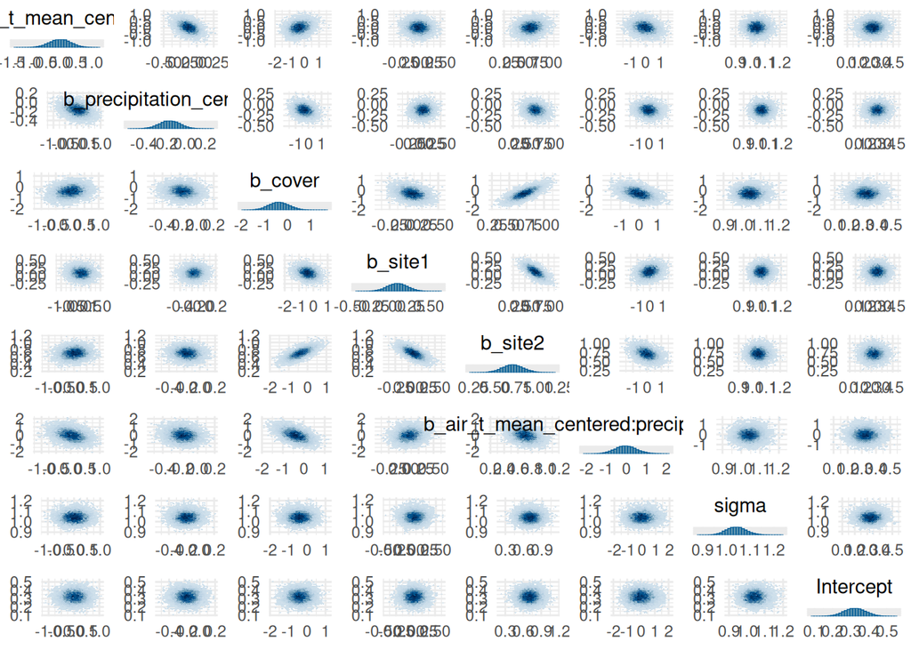

```r
my_mcmc_pairs(fit_overl_itp)
```

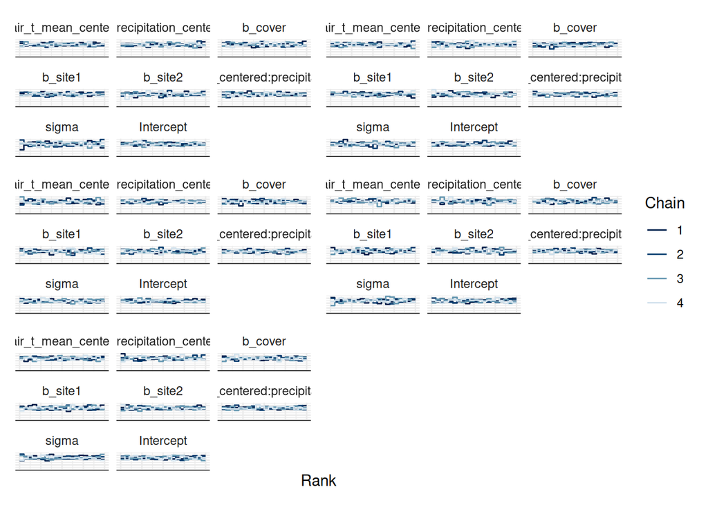

```r
trank(fit_overl_itp)
```

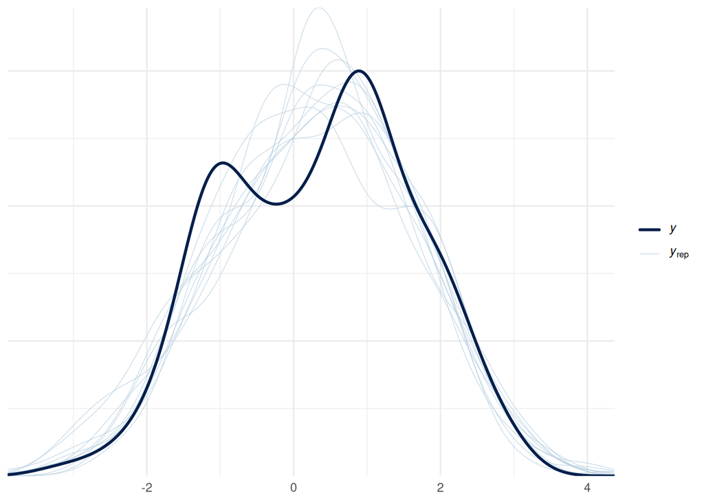

```r
pp_check(fit_overl_itp)
```

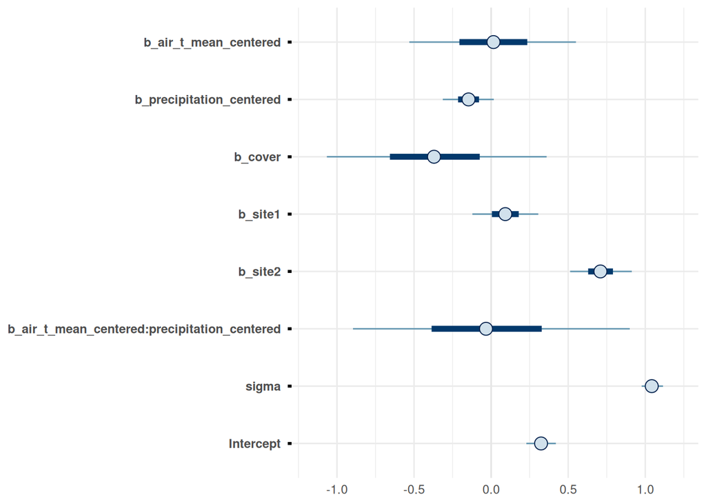

```r
mcmc_intervals(fit_overl_itp, pars = show)
```

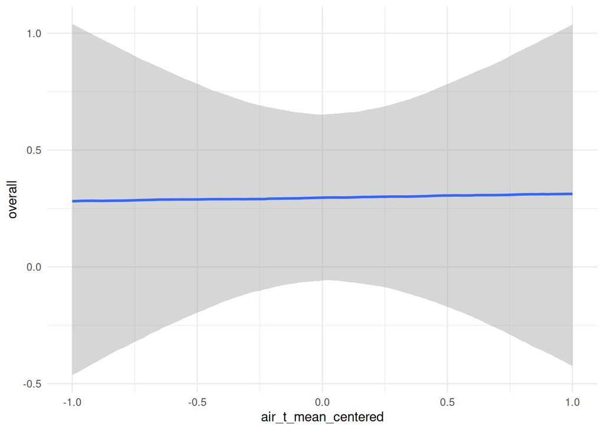

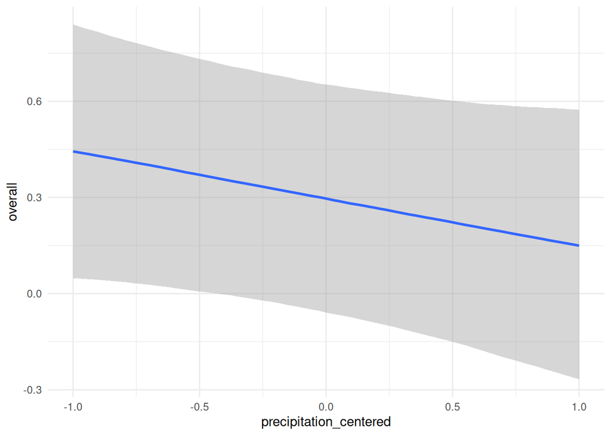

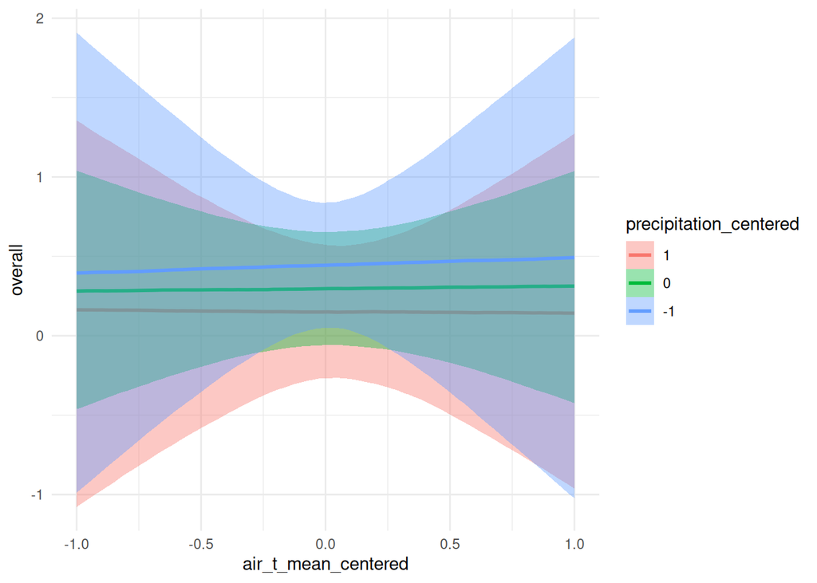

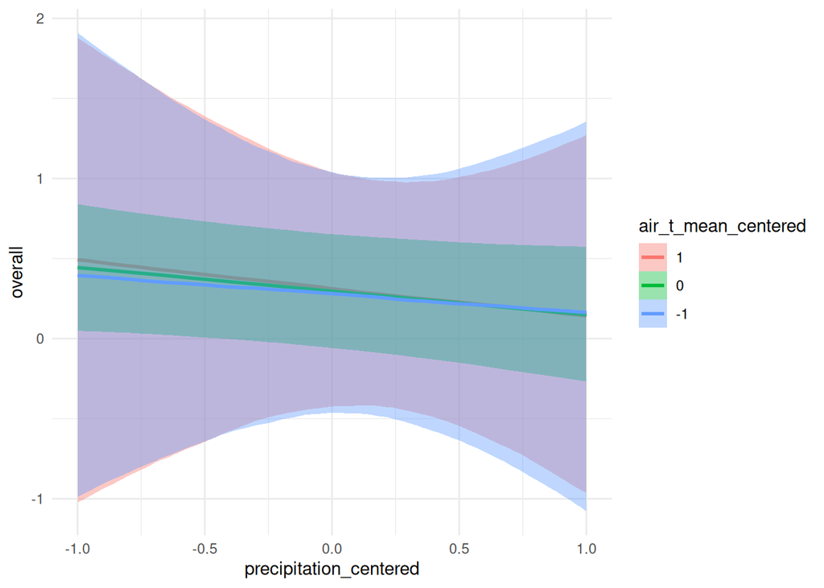

```r
my_ceffects(fit_overl_itp)
```

# 10 Explained vs. subplot variance

The variance explained by the models on new data can be assessed through the Bayesian R<sup>2</sup>. A slightly different question, unlinked from the issue of how of the FD variation is explained by weather, is to relate the subplot variation within site-years to the variation between site-years. It is evident from the box-plots that the FD-SES variation among subplots is large compared to the variation between sites and years. This can be quantified through a specialized model that has an intercept for each site-year. Here, R<sup>2</sup> is not used as a measure of model fit, for which it has many flaws, because this kind of model is obviously overfit. Rather, it is used to assess the proportion of variance explained, as intended for the Bayesian version (Gelman et al. 2019). By recalling the Bayesian R<sup>2</sup> formula:

$\frac{Explained~variance}{Explained~variance + Residual~variance}$

Since the residual variance of this model is the subplot variance within site-years, this can be expressed as:

$1-\frac{Explained~variance}{Explained~variance + Residual~variance}=\frac{Residual~variance}{Explained~variance + Residual~variance}$

```r
prior <- c(prior(student_t(3, 0, 0.7), class = "Intercept"),
           prior(student_t(3, 0, 0.7), class = "b"),
           prior(student_t(3, 0, 0.5), class = "sigma", lb = 0))

fit_subplot_above <- brm(above ~ site:year,
                         data = results_sites,
                         prior = prior,
                         seed = 2853,
                         file = "fits/extra/subplot.above",
                         file_refit = "never")

(1 - bayes_R2(fit_subplot_above, summary = F)) |>
  mean_qi()
```

| y | ymin | ymax | .width | .point | .interval |
| --- | --- | --- | --- | --- | --- |
| 0.554 | 0.504 | 0.608 | 0.95 | mean | qi |

```r
fit_subplot_below <- brm(below ~ site:year,
                         data = results_sites,
                         prior = prior,
                         seed = 2853,
                         file = "fits/extra/subplot.below",
                         file_refit = "never")

(1 - bayes_R2(fit_subplot_below, summary = F)) |>
  mean_qi()
```

| y | ymin | ymax | .width | .point | .interval |
| --- | --- | --- | --- | --- | --- |
| 0.788 | 0.734 | 0.84 | 0.95 | mean | qi |

```r
fit_subplot_overall <- brm(overall ~ site:year,
                         data = results_sites,
                         prior = prior,
                         seed = 2853,
                         file = "fits/extra/subplot.overall",
                         file_refit = "never")

(1 - bayes_R2(fit_subplot_overall, summary = F)) |>
  mean_qi()
```

| y | ymin | ymax | .width | .point | .interval |
| --- | --- | --- | --- | --- | --- |
| 0.613 | 0.563 | 0.669 | 0.95 | mean | qi |

# 11 Store fits

```r
#load brms fits
fits <- list.files("fits/fd", pattern = "\\.rds$", full.names = T) |>
  map(readRDS) |>
  as_tibble_col(column_name = "fit")

#organize the models
fits <- fits |>
  mutate(name = list.files("fits/fd", pattern = "\\.rds$") |>
           str_remove("\\.rds$") |>
           str_replace_all("\\.", "_"),
  trait = word(name, 1, sep = "_"),
  type = word(name, 2, sep = "_"))

#fix names
fits <- fits |>
  mutate(trait = if_else(trait == "overl", "overall", trait))

#add data
fits <- fits |>
  mutate(data = map(name, \(x) if (str_detect(x, "ofd")) ofd else rlang::env_get(topenv(), x)),
         data = map2(type, data,
                     \(x, y) if (x == "ofd"){
                       y
                     } else {
                       #get average of imputations
                       map(y, \(t) t |>
                             mutate(obs_id = row_number())) |>
                         bind_rows(.id = "imp") |>
                         summarise(across(where(is.numeric), mean),
                                   .by = c(site, obs_id)) |>
                         select(!obs_id)
                     }))
```

# 12 Diagnostics

## 12.1 Check number of divergent transitions

```r
fits <- fits |>
    mutate(n_divergent = map_int(fit,
                   \(x) nuts_params(x) |>
                     filter(Parameter == "divergent__" & Value == 1) |>
                     nrow()))

fits |>
  select(!c(data, fit)) |>
  filter(n_divergent > 0)
```

| name | trait | type | n_divergent |
| --- | --- | --- | --- |

## 12.2 Pareto *k*

```r
fits <- fits |>
  mutate(n_pareto_k = map_int(fit, \(x) x |>
                          log_lik() |>
                          (\(ll) psis(-ll))() |>
                          loo::pareto_k_ids() |>
                          length()))

fits |>
  select(!c(data, fit)) |>
  filter(n_pareto_k > 0)
```

| name | trait | type | n_divergent | n_pareto_k |
| --- | --- | --- | --- | --- |

It must be pointed out that the pareto *k* diagnostic is not completely ready to handle multiple imputation. It uses the first imputed dataset, but influential points could arise simply because the posterior is calculated not just from that data.

# 13 Save results

```r
fits |>
  select(!c(n_divergent, n_pareto_k)) |>
  saveRDS("intermediate/fits_fd.rds")
```

## References

Gelman, Andrew, Ben Goodrich, Jonah Gabry, and Aki Vehtari. 2019. “R-Squared for Bayesian Regression Models.” *The American Statistician* 73 (3): 307–9. https://doi.org/10.1080/00031305.2018.1549100.